# DuMOAR RNA-Seq

Laura Spencer

2022-10-20

### Load libraries and source scripts

```r
#### Load libraries and source scripts

source("../references/biostats.R")
#source("../references/iLOO.R")
`%!in%` = Negate(`%in%`)

# Add all required libraries that are installed with install.packages() here
list.of.packages <- c("RCurl", "tidyverse", "vegan", "pheatmap", "pastecs", "factoextra", "FactoMineR", "RColorBrewer", "tibble", "reshape2", "cowplot", "clipr", "janitor", "ggpubr", "forcats", "apeglm", "car", "vsn", "devtools", "grid", "gridGraphics", "Rfast", "dendextend", "RColorBrewer", "scales", "VennDiagram", "colorspace")

# Add all libraries that are installed using BiocManager here
bioconductor.packages <- c("DESeq2", "WGCNA")

# # Install BiocManager if needed
# if(!requireNamespace("BiocManager", quietly = TRUE)) install.packages("BiocManager")
#
# # Get names of all required packages that aren't installed
# new.packages <- list.of.packages[!(list.of.packages %in% installed.packages()[, "Package"])]
# new.bioc.packages <- bioconductor.packages[!(bioconductor.packages %in% installed.packages()[, "Package"])]
# # Install all new packages
# if(length(new.packages)) install.packages(new.packages)
# if(length(new.bioc.packages)) BiocManager::install(new.bioc.packages)

# Load all required libraries
all.packages <- c(list.of.packages, bioconductor.packages)
lapply(all.packages, FUN = function(X) {
  do.call("require", list(X))
})

# Github packages
#install_github("pmartinezarbizu/pairwiseAdonis/pairwiseAdonis")
library(pairwiseAdonis)

`%!in%` = Negate(`%in%`)
```

# Pre-processing gene counts

### Import counts

```r
counts <- data.frame(read.table("../results/STAR/all.ReadsPerGene.out.tab", header = T, stringsAsFactors = F, fill = FALSE)) %>%
  column_to_rownames(var="Genes")
```

### Import sample info

```r
sample.info.rna <- read_sheet("https://docs.google.com/spreadsheets/d/1ym0XnYVts98tIUCn0kIaU6VuvqxzV7LoSx9RHwLdiIs/edit?usp=sharing", "data_071119collection") %>%
 clean_names() %>% dplyr::select(sample, tank, high_or_low_co2, developmental_stage) %>%
  mutate(sample=gsub("\\-", "\\.", sample)) %>%
  mutate_at(vars(tank, high_or_low_co2, developmental_stage), as.factor) %>%
  filter(sample %in% colnames(counts))
```

```
## ! Using an auto-discovered, cached token.
```

```
##   To suppress this message, modify your code or options to clearly consent to
##   the use of a cached token.
```

```
##   See gargle's "Non-interactive auth" vignette for more details:
```

```
## ℹ The googlesheets4 package is using a cached token for
##   'laura.spencer@noaa.gov'.
```

```
## Auto-refreshing stale OAuth token.
```

```
## ✔ Reading from "OA Crab Sample Collection 071119".
```

```
## ✔ Range ''data_071119collection''.
```

### Summarize counts

```r
print(paste("Number of samples:", ncol(counts)))
```

```
## [1] "Number of samples: 24"
```

```r
print(paste("Total number of genes in dataframe:", prettyNum(nrow(counts), big.mark = ","), sep=" "))
```

```
## [1] "Total number of genes in dataframe: 43,800"
```

```r
print(paste("Average number of genes per sample:", prettyNum(mean(colSums(counts != 0)) %>% round(), big.mark = ","), sep=" "))
```

```
## [1] "Average number of genes per sample: 16,502"
```

```r
print(paste("Total counts, all samples:", prettyNum(sum(colSums(counts)), big.mark = ","), sep=" "))
```

```
## [1] "Total counts, all samples: 25,469,323"
```

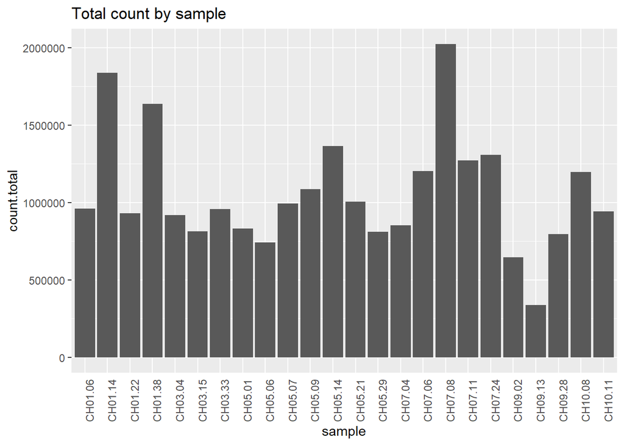

```r
#inspect total counts by sample
# ggplotly(
   ggplot(data.frame(colSums(counts)) %>%
            dplyr::rename(count.total = 1) %>% rownames_to_column(var="sample")) +
     geom_bar(aes(x=sample, y=count.total), stat = "identity") + ggtitle("Total count by sample") +
              theme(axis.text.x = element_text(angle = 90), axis.ticks.x = element_blank())#)
```

### Assess MEGAN results

Does % alignment match the megan % of reads assigned to arthropoda?

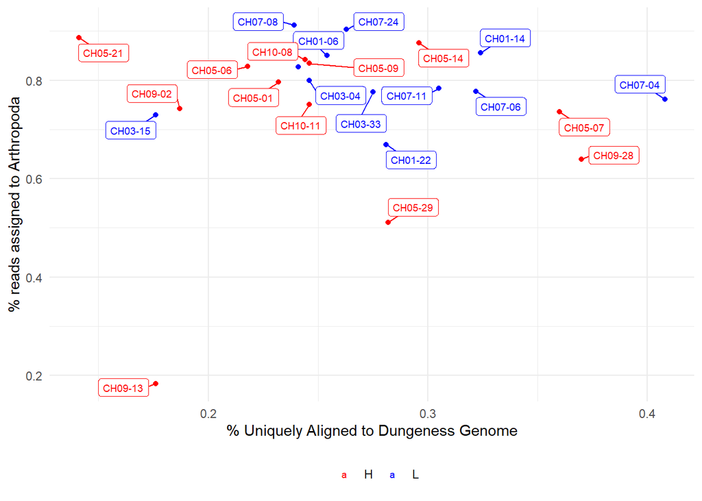

```r
load(file = "../results/MEGAN/megan.df.plot")
read.csv("../results/STAR/star-align-all-data.csv", header = T) %>%
  left_join(megan.df.plot, by = "sample") %>%
  filter(phylum=="Arthropoda") %>% filter(!grepl("R2",sample.read)) %>%
  ggplot(aes(x=uniquely.aligned, y=fraction, color=high_or_low_co2, label=sample)) +
  geom_point() + theme_minimal() +
  geom_label_repel(size=2.5, min.segment.length=0.15, aes(colour=high_or_low_co2)) +
  scale_color_manual(values = c("red", "blue")) +
  theme(legend.position = "bottom", legend.title = element_blank()) +
  xlab("% Uniquely Aligned to Dungeness Genome") + ylab("% reads assigned to Arthropoda")
```

### Optional filters

#### OPTIONAL: Filter whole samples

Remove whole samples from the data set and sample info here if needed

```r
# remove.list <- c("PCG194", "PCG137")
# counts <- counts[ , -which(names(counts) %in% remove.list)]
# sample.info.rna <- sample.info.rna[ -which(sample.info.rna$vial_label %in% remove.list), ]
#
# # resave sample info object
# save(sample.info.rna, file="../data/sample.info.rna")
#
# nrow(sample.info.rna) == ncol(counts) #should = TRUE
```

#### OPTIONAL: Filter whole scaffolds

This code provides the option to remove data that mapped to scaffolds 105+. This is possibly beneficial because I don’t know whether or not those scaffolds are also included within scaffolds 1-104 (i.e. the chromosomes).

NOTE: For exploration purposes I will NOT remove them, and will see if expressed data mapping to scaffolds 105+ have the exact same genes/counts as on chromosomes.

After preliminary examination of blast results (by looking at genes, lengths, and counts) it’s difficult to tell whether the scaffolds 105+ are subsets of the chromosomes 1-104. For now I will retain scaffolds 105+.

```r
# counts <- counts %>% separate(Chr, into = c("X", "Y", "scaffold"), sep = "_", remove = F) %>%
#   mutate(scaffold=as.integer(scaffold)) %>% filter(scaffold<=104) %>% dplyr::select(-X, -Y, -scaffold)
```

#### Optional: filter genes that are outliers in outlier samples

```r
# counts <- counts[-which(rownames(counts) %in% outliers),]
```

#### Transpose dataframe

In the counts.t dataframe each row = a sample (aka “objects”), and each column = genes (aka “variables”)

```r
#str(counts) #columns #1-#5 contain extraneous gene info (chr, start, end, strand, length).
counts.t <- as.data.frame(t(counts)) #transform data to have each sample a row, each column a gene
```

### Remove low-frequency genes

NOTE: Should i do this? DESeq2 throws out low-frequency genes anyway, BUT other folks do pre-filter. For example in https://doi.org/10.1186/s12864-017-4392-0 “Genes with mean count less than ten across all samples were removed.”

```r
keep1 <- colMeans(counts.t, na.rm=TRUE) >= 10 #identify genes with mean count >= 10 across all samples (excluding NAs = 10)
keep2 <- rowSums( counts >= 30 ) >= 0.1*24 #identify genes with counts>=30 across at minimum 10% of the samples
keep <- unique(c(names(which(keep1 == T)), names(which(keep2 == T)))) # list of genes meeting one of the two above criteria
counts.ts <- counts.t[,keep]
#counts.ts <- counts.t #execute this line to keep ALL genes
```

#### Save counts file, and transformed counts file

```r
save(counts, file = "../results/STAR/counts")
save(counts.t, file = "../results/STAR/counts.t")
save(counts.ts, file = "../results/STAR/counts.ts")
```

#### Annotate gene count matrix

```r
# IMPORTANT NOTE: to use data for ALL genes, use object "counts.t". To remove low-frequency genes, use object "counts.ts"

# merge count data with sample key, reset row names as sample names, and arrange by treatment
counts.tk <- merge(x=sample.info.rna, by.x="sample", y=counts.ts, by.y="row.names") %>%
  arrange(high_or_low_co2, tank)  %>% column_to_rownames(var="sample") %>% droplevels()

head(counts.tk[1:8]) #check out results of merge/arrange
```

```
##         tank high_or_low_co2 developmental_stage M_mag.00g000100-v1.0.a1
## CH05.01    2               H                  J7                      45
## CH05.14    2               H                  J6                      36
## CH05.21    2               H                  J7                       7
## CH05.07    4               H                 J6*                      35
## CH05.09    4               H                 J6*                      34
## CH05.29    4               H                  J7                      71
##         M_mag.00g000120-v1.0.a1 M_mag.00g000240-v1.0.a1 M_mag.00g000260-v1.0.a1
## CH05.01                      58                      34                       7
## CH05.14                      54                      34                       8
## CH05.21                       9                       9                       5
## CH05.07                      77                      21                      22
## CH05.09                      40                      27                      19
## CH05.29                      79                      25                      13
##         M_mag.00g000270-v1.0.a1
## CH05.01                      18
## CH05.14                      43
## CH05.21                       8
## CH05.07                      81
## CH05.09                      20
## CH05.29                      50
```

# Library summary stats

```r
print(paste("# genes before filtering:", ncol(counts.t)))
```

```
## [1] "# genes before filtering: 43800"
```

```r
print(paste("# genes remaining after pre-filtering:", ncol(counts.ts)))
```

```
## [1] "# genes remaining after pre-filtering: 7075"
```

```r
print(paste("# of genes dropped:", ncol(counts.t) - ncol(counts.ts), sep=" "))
```

```
## [1] "# of genes dropped: 36725"
```

```r
print(paste("% of fragments remaining after pre-filtering: ", signif(100*sum(counts.ts)/sum(counts.t), digits = 5), "%", sep=""))
```

```
## [1] "% of fragments remaining after pre-filtering: 95.551%"
```

```r
print(paste("Number of fragments dropped: ", signif(sum(counts.t)-sum(counts.ts), digits = 5)))
```

```
## [1] "Number of fragments dropped:  1133100"
```

```r
print(paste("% of fragments dropped: ", signif(100*(sum(counts.t)-sum(counts.ts))/sum(counts.t), digits = 5), "%", sep=""))
```

```
## [1] "% of fragments dropped: 4.4489%"
```

```r
print(paste("Number of fragments remaining: ", signif(sum(counts.ts), digits = 5)))
```

```
## [1] "Number of fragments remaining:  24336000"
```

#### Inspect read distribution before & after filtering

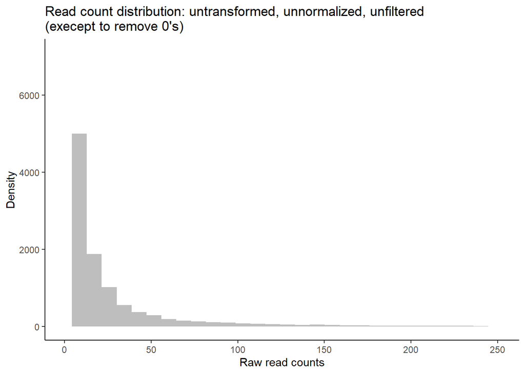

```r
# Plot distribution of unfiltered read counts across all samples
#ggplotly(
ggplot(data = data.frame(rowMeans(counts)),
       aes(x = rowMeans.counts.)) +
  geom_histogram(fill = "grey") +
  xlim(1, 250) +
  theme_classic() +
  labs(title = "Distribution of unfiltered reads") +
  labs(y = "Density", x = "Raw read counts",
  title = "Read count distribution: untransformed, unnormalized, unfiltered\n(execept to remove 0's)")#)
```

#### No. of fragments per sample?

```r
data.frame(rowSums(counts.ts)) %>%
                  dplyr::rename(read.total = 1) %>%
                  rownames_to_column(var="sample") %>% #summary()
dplyr::summarise(mean=round(mean(read.total, na.rm=T)),
          sd=round(sd(read.total, na.rm=T)),
          se=round(sd/sqrt(length(sample))),
          median=median(read.total),
          min=min(read.total),
          max=max(read.total)) %>% t() %>% as.data.frame() %>%
  dplyr::mutate(V1=prettyNum(V1, big.mark = ",")) %>%
  dplyr::rename("fragments.per.sample"="V1") #use this to average across all samples
```

```
##        fragments.per.sample
## mean              1,014,009
## sd                  371,394
## se                   75,810
## median              918,780
## min                 304,200
## max               1,978,924
```

#### Did the no. of fragments per treatment differ?

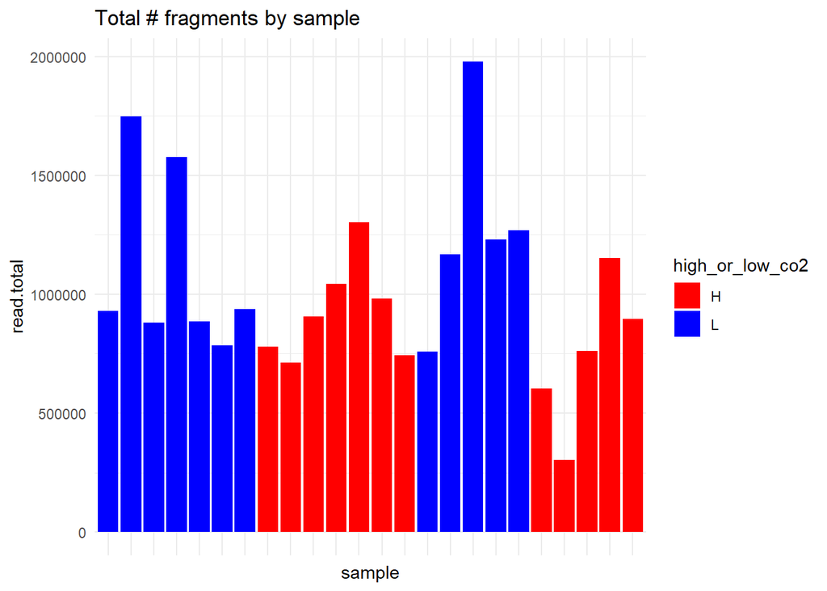

```r
fragments <- data.frame(rowSums(counts.ts)) %>%
                  dplyr::rename(read.total = 1) %>%
                  rownames_to_column(var="sample") %>%
  left_join(sample.info.rna %>% dplyr::select(sample, high_or_low_co2, developmental_stage), by="sample")


#ggplotly(
ggplot(data = fragments) +
  geom_bar(aes(x=sample, y=read.total, fill=high_or_low_co2), stat = "identity") +
  ggtitle("Total # fragments by sample") + theme_minimal() +
  scale_fill_manual(values=c("L"= "blue", "H"="red")) +
  theme(axis.text.x = element_blank(), axis.ticks.x = element_blank())#)
```

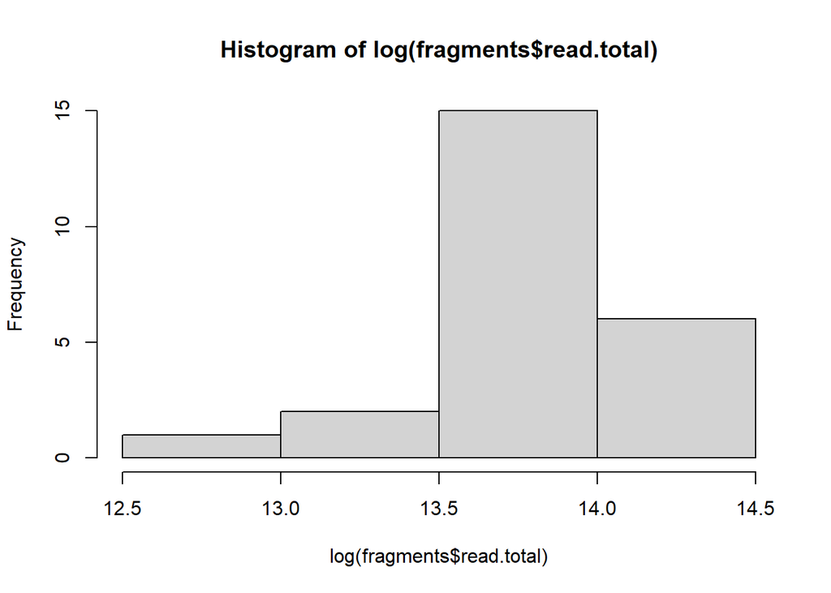

```r
hist(log(fragments$read.total))
```

```r
shapiro.test(log(fragments$read.total))
```

```
##
##  Shapiro-Wilk normality test
##
## data:  log(fragments$read.total)
## W = 0.93455, p-value = 0.1232
```

```r
anova(lm(log(read.total) ~ high_or_low_co2, fragments))
```

```
## Analysis of Variance Table
##
## Response: log(read.total)
##                 Df  Sum Sq Mean Sq F value  Pr(>F)
## high_or_low_co2  1 0.67431 0.67431  5.5535 0.02776 *
## Residuals       22 2.67129 0.12142
## ---
## Signif. codes:  0 '***' 0.001 '**' 0.01 '*' 0.05 '.' 0.1 ' ' 1
```

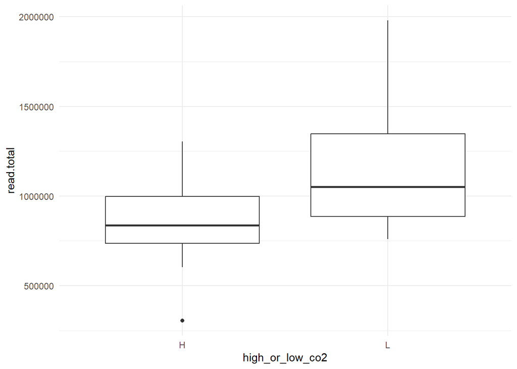

```r
ggplot(fragments, aes(x=high_or_low_co2, y=read.total)) + geom_boxplot() + theme_minimal()
```

#### How many samples per treatment?

```r
fragments %>% group_by(high_or_low_co2) %>% tally()
```

```
## # A tibble: 2 × 2
##   high_or_low_co2     n
##   <fct>           <int>
## 1 H                  12
## 2 L                  12
```

```r
fragments %>% group_by(high_or_low_co2, developmental_stage) %>% tally()
```

```
## # A tibble: 6 × 3
## # Groups:   high_or_low_co2 [2]
##   high_or_low_co2 developmental_stage     n
##   <fct>           <fct>               <int>
## 1 H               J6                      5
## 2 H               J6*                     2
## 3 H               J7                      5
## 4 L               J6                      7
## 5 L               J6*                     1
## 6 L               J7                      4
```

#### How many genes total in the filtered count matrix?

```r
prettyNum(ncol(counts.ts),big.mark = ",")
```

```
## [1] "7,075"
```

#### What’s the average no. of genes per sample?

```r
data.frame(rowSums(counts.ts != 0)) %>%
                  dplyr::rename(count.total = 1) %>%
                  rownames_to_column(var="sample") %>%
  summarise(mean=round(mean(count.total, na.rm=T)),
            sd=round(sd(count.total, na.rm=T)),
            se=round(sd/sqrt(length(sample))),
            median=median(count.total, na.rm=T),
            min=min(count.total, na.rm=T),
            max=max(count.total, na.rm=T)) %>% t() %>% as.data.frame() %>%
  mutate(V1=prettyNum(V1, big.mark = ",")) %>%
  dplyr::rename("genes.per.sample"="V1")
```

```
##        genes.per.sample
## mean              6,890
## sd                  183
## se                   37
## median            6,964
## min               6,433
## max               7,050
```

#### No. of genes/sample before & after filtering

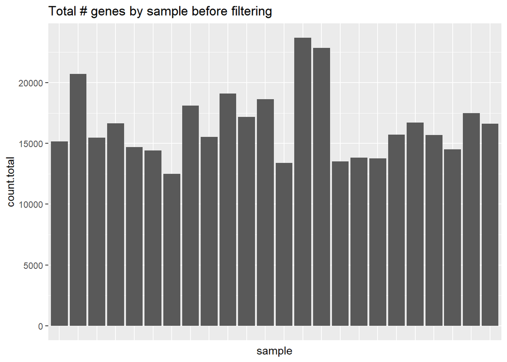

```r
#ggplotly(
ggplot(data = data.frame(rowSums(counts.t != 0, na.rm=TRUE)) %>%
                  dplyr::rename(count.total = 1) %>%
                  rownames_to_column(var="sample")) +
           geom_bar(aes(x=sample, y=count.total), stat = "identity") + ggtitle("Total # genes by sample before filtering") +
             theme(axis.text.x = element_blank(), axis.ticks.x = element_blank())#)
```

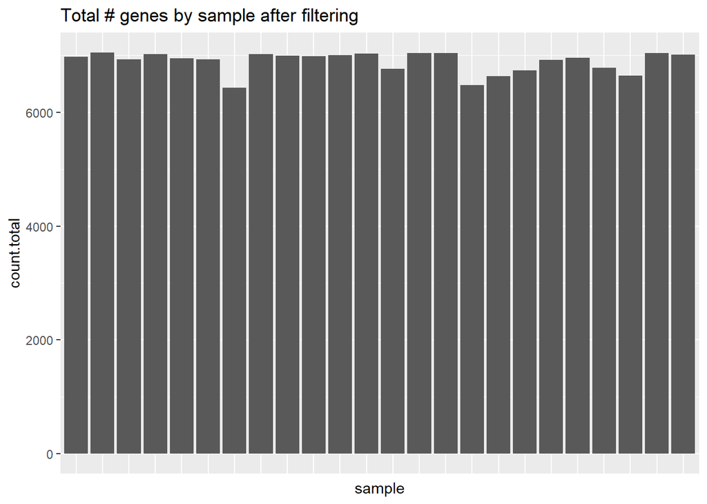

```r
ggplot(data = data.frame(rowSums(counts.ts != 0, na.rm=TRUE)) %>%
                  dplyr::rename(count.total = 1) %>%
                  rownames_to_column(var="sample")) +
           geom_bar(aes(x=sample, y=count.total), stat = "identity") + ggtitle("Total # genes by sample after filtering") +
             theme(axis.text.x = element_blank(), axis.ticks.x = element_blank())#)
```

# start DESeq2, unsupervised analyses

#### Ensure correct sample order for DESeq2

```r
# NOTE: It is absolutely critical that the **columns of the count matrix** and the **rows of the column data (information about samples)** are in the same order. DESeq2 will not make guesses as to which column of the count matrix belongs to which row of the column data, these must be provided to DESeq2 already in consistent order.

all(rownames(counts.tk) == counts.tk[-1:-3] %>% t() %>% colnames()) #check that rownames of untransformed matrix match column names of transformed matrix. Should print 'TRUE'
```

```
## [1] TRUE
```

#### Generate DESeq dataset

```r
dds.treatment <- DESeqDataSetFromMatrix(countData = counts.tk[-1:-3] %>% t(),
                              colData = counts.tk[,"high_or_low_co2", drop=FALSE] ,
                              design = ~ high_or_low_co2)
```

#### Transform data for visualization

```r
vsd.treatment <- varianceStabilizingTransformation(dds.treatment, blind=FALSE)
save(vsd.treatment, file = "../results/DESeq2/vsd.treatment")
```

### Heat map

Uses top 10% most variable genes, VSD-transformed counts

```r
# calculate CV for each gene across all samples
most.variable <- assay(vsd.treatment) %>% as.data.frame() %>%
  rownames_to_column(var = "gene") %>%
  rowwise() %>%
  dplyr::mutate(
     sd = sd(c_across(-gene)),
     mean = mean(c_across(-gene)),
     cv = sd/mean) %>%
  #column_to_rownames("gene") %>%
  arrange(desc(cv)) %>%
# subset top 10% of most variable genes
  head(n=round(0.1*nrow(assay(vsd.treatment)))) %>%
  dplyr::select(gene) %>% unlist() %>% as.vector()

length(most.variable)
```

```
## [1] 708
```

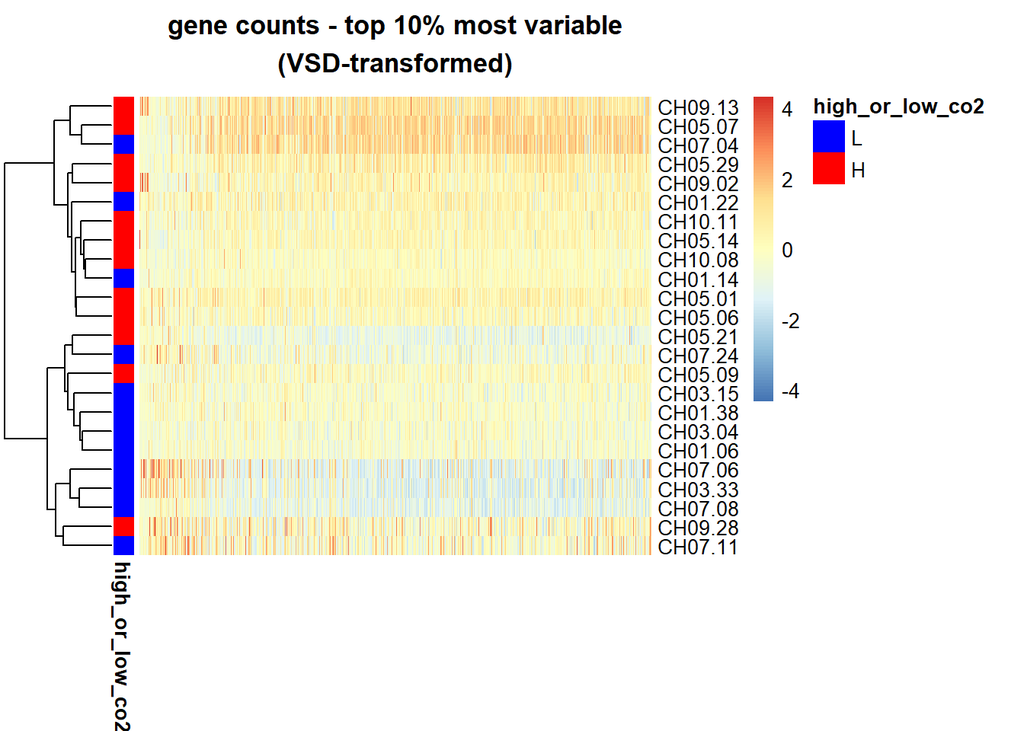

```r
# Generate heat map / cluster those top 10% most variable genes
cluster.most.variable <- pheatmap(t(assay(vsd.treatment))[,most.variable],
         Rowv=NA, Colv=NA, na.rm = TRUE, xlab = NA, scale="column",
                     show_colnames =FALSE, cluster_cols = FALSE, cluster_rows = TRUE,
         annotation_colors = list(high_or_low_co2=c(`L`= "blue", `H`="red")),
         annotation_row=as.data.frame(colData(vsd.treatment)[,c("high_or_low_co2"), drop=FALSE]),
         main = "gene counts - top 10% most variable\n(VSD-transformed)")
```

### Hierarchical clustering

NOTE: this was generated by the pheatmap function in the previous code chunk

```r
# Just plot hierarchical cluster, color-code sample by treatment, or by tank number
cluster.dendo <- as.dendrogram(cluster.most.variable$tree_row)
#plot(cluster.dendo) # bare bones dendogram
#order.dendrogram(cluster.dendo) # to find out the order of the sample labels

# Create a dataframe ordered the same as the dendogram for annotation purposes
dendo.df <- sample.info.rna[match(cluster.most.variable$tree_row$labels, sample.info.rna$sample),c("sample", "high_or_low_co2", "tank")]
all(dendo.df$sample == cluster.most.variable$tree_row$labels) # Should == TRUE
```

```
## [1] TRUE
```

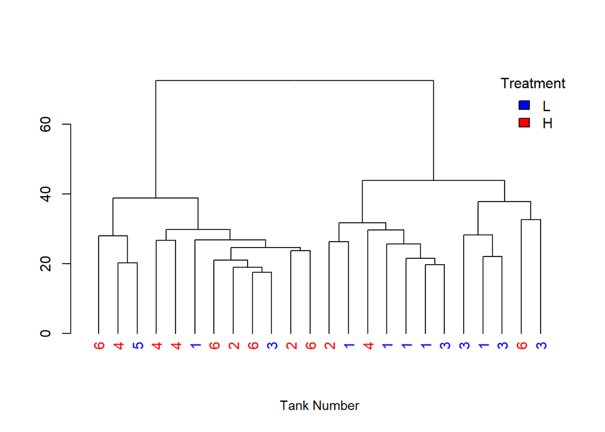

```r
# Create color coding vectors
colorCodes.treat <- c(`L`= "blue", `H`="red")
colorCodes.tank <- colorRampPalette(brewer.pal(12, "Paired"))(length(levels(sample.info.rna$tank)))

# # Color code sample names by treatment
#labels_colors(cluster.dendo) <- colorCodes.treat[as.character(dendo.df$treatment[order.dendrogram(cluster.dendo)])]
#plot(cluster.dendo, xlab="Sample (color=treatment)") # plot with sample names color coded by treatment

# Plot dendogram color-code by treatment, but labels are tank number
labels(cluster.dendo) <- dendo.df$tank[order.dendrogram(cluster.dendo)]
labels_colors(cluster.dendo) <- colorCodes.treat[as.character(dendo.df$high_or_low_co2[order.dendrogram(cluster.dendo)])]
plot(cluster.dendo, xlab="Tank Number", cex.lab=0.9) # plot with sample names color coded by tank
legend("topright", title = "Treatment", bty="n", legend =c("L", "H"), fill = c("blue","red"))
```

```r
# # Color code sample names by tank
# labels_colors(cluster.dendo) <- colorCodes.tank[dendo.df$tank][order.dendrogram(cluster.dendo)]
# plot(cluster.dendo, xlab="Sample (color=tank)") # plot with sample names color coded by tank

# # A sub tree - looking at branches
# par(cex = 1)
# plot(cluster.dendo[[1]], horiz = TRUE)
```

```r
#
# #### Save variance-stabilization normalized gene counts x sample matrix, annotated for later use
#
# ####**NOTE: Here forward I primarily work with the vsd.treatment object, so I can do pairwise treatment contrasts**
#
# counts.trans <- assay(vsd.treatment) %>% t() %>% as.matrix() %>% as.data.frame() %>%
#   rownames_to_column(var = "sample") %>%
#   left_join(sample.info.rna[,c("sample", "treatment", "tank", "temperature", "ph")], by = c("sample"="vial_label")) %>%
#   column_to_rownames(var = "sample") %>%
#   dplyr::select(treatment, temperature, ph, tank, everything()) %>%
#   mutate(Treatment=factor(treatment, levels=c("3_low", "6_amb", "6_low", "10_amb", "10_low"))) %>%
#   mutate(temperature=factor(temperature, levels=c("3", "6", "10"))) %>%
#   mutate(ph=factor(ph, levels=c("amb", "low")))
# save(counts.trans, file = "../results/star/counts.trans")
```

### PCA’s

```r
# To view the the guts of the PlotPCA function in DESeq2, execute this code chunk. It reveals that, by default, it only uses the top 500 most influential genes to plot the PCA!

#getMethod("plotPCA","DESeqTransform")
```

#### PCAs using DESeq2

NOTE: Hover over points to see the sample numbers

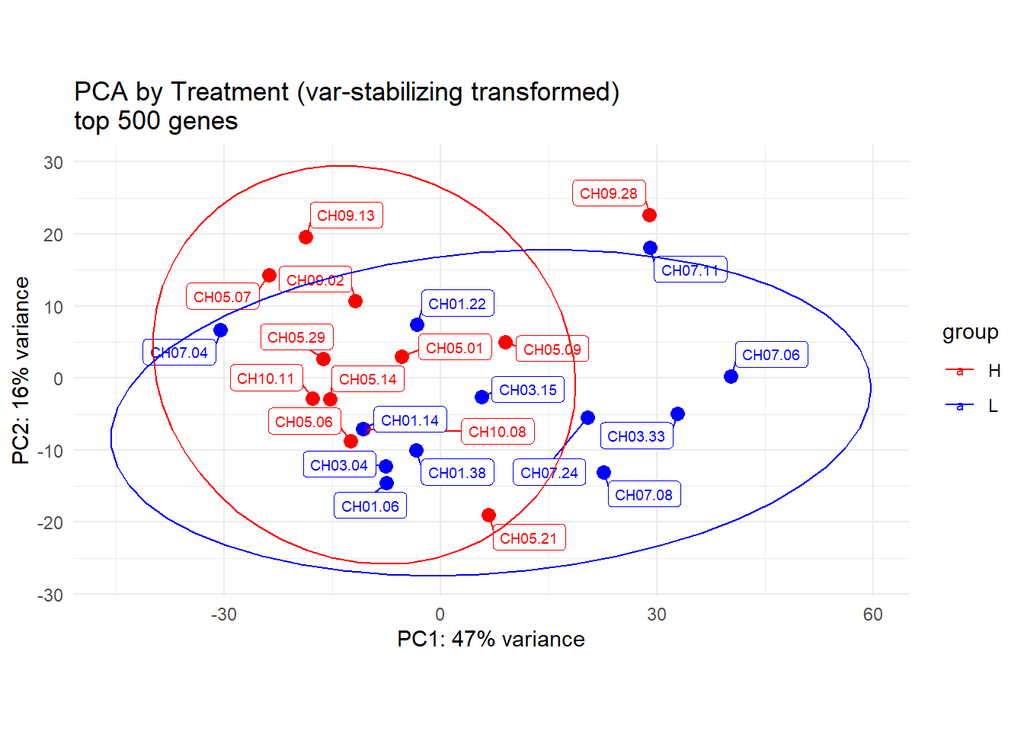

```r
# Generate PCA with points color coded by pH Treatment with various number of top genes to use for principal components, selected by highest row variance

#ggplotly(
  plotPCA(vsd.treatment, intgroup="high_or_low_co2", ntop=500) +
           ggtitle("PCA by Treatment (var-stabilizing transformed)\ntop 500 genes") +
    geom_point(size=2, aes(text=colnames(vsd.treatment))) +
      scale_color_manual(values=c("L"= "blue", "H"="red")) +
    geom_label_repel(size=2.5, min.segment.length=0.15, aes(label=colnames(vsd.treatment))) +
      theme_minimal()+ stat_ellipse() #, tooltip = "text")
```

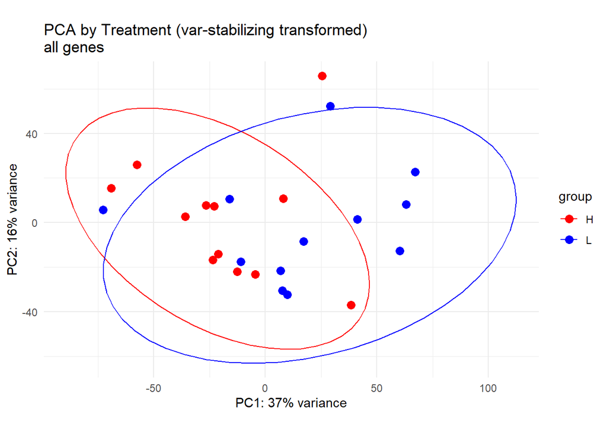

```r
#ggplotly(
  plotPCA(vsd.treatment, intgroup="high_or_low_co2", ntop=nrow(assay(vsd.treatment))) +
           ggtitle("PCA by Treatment (var-stabilizing transformed)\nall genes") +
    geom_point(size=3, aes(text=colnames(vsd.treatment))) +
      scale_color_manual(values=c("L"= "blue", "H"="red")) +
    theme_minimal()+ stat_ellipse() #, tooltip = "text")
```

#### PCAs using prcomp

This enables screeplot to ID significant PCs, calculates variance, etc.

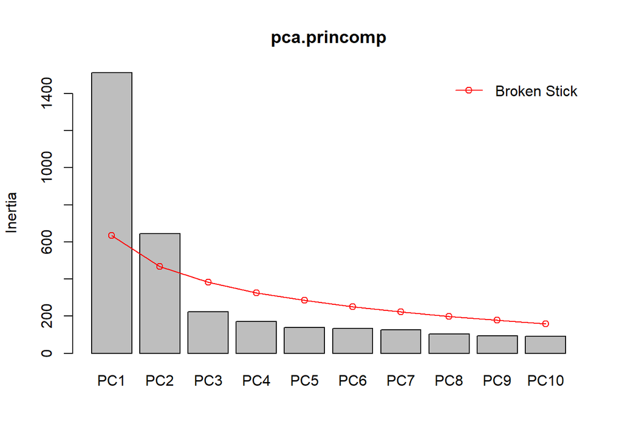

```r
#pca.princomp <- prcomp(cov(assay(vsd.pH)), scale=F) #scale=F for variance-covariance matrix
pca.princomp <- prcomp(t(assay(vsd.treatment))) # using the same code that's under the hood of PlotPCA but using all genes
screeplot(pca.princomp, bstick=TRUE) #looks like PC 1-2 are significant
```

```r
pca.eigenval(pca.princomp) #The Proporation of Variance = %variance
```

```
## Importance of components:
```

```
##                                 PC1         PC2         PC3         PC4
## Variance(eigenvalue)   1511.4640782 643.6024692 223.4385489 170.1011242
## Proportion of Variance    0.3747462   0.1595722   0.0553984   0.0421742
## Cumulative Proportion     0.3747462   0.5343184   0.5897168   0.6318910
## Broken-stick value        3.7759582   2.7759582   2.2759582   1.9426248
##                                PC5         PC6         PC7         PC8
## Variance(eigenvalue)   139.6352714 134.1871911 127.3345985 104.6895204
## Proportion of Variance   0.0346206   0.0332698   0.0315708   0.0259563
## Cumulative Proportion    0.6665116   0.6997814   0.7313522   0.7573085
## Broken-stick value       1.6926248   1.4926248   1.3259582   1.1831010
##                               PC9       PC10       PC11       PC12       PC13
## Variance(eigenvalue)   94.3888175 90.2212707 88.4388089 81.5762203 72.1841021
## Proportion of Variance  0.0234024  0.0223691  0.0219272  0.0202257  0.0178970
## Cumulative Proportion   0.7807109  0.8030800  0.8250072  0.8452328  0.8631299
## Broken-stick value      1.0581010  0.9469899  0.8469899  0.7560808  0.6727475
##                              PC14       PC15       PC16       PC17       PC18
## Variance(eigenvalue)   69.0166422 64.9168667 60.7034661 58.9835312 56.1767851
## Proportion of Variance  0.0171117  0.0160952  0.0150506  0.0146241  0.0139282
## Cumulative Proportion   0.8802416  0.8963368  0.9113874  0.9260115  0.9399397
## Broken-stick value      0.5958244  0.5243959  0.4577292  0.3952292  0.3364057
##                              PC19       PC20       PC21       PC22       PC23
## Variance(eigenvalue)   53.8732533 52.7235346 51.1239604 47.1402002 37.3801323
## Proportion of Variance  0.0133571  0.0130721  0.0126755  0.0116877  0.0092679
## Cumulative Proportion   0.9532969  0.9663689  0.9790444  0.9907321  1.0000000
## Broken-stick value      0.2808501  0.2282185  0.1782185  0.1305995  0.0851449
##                             PC24
## Variance(eigenvalue)   0.0000000
## Proportion of Variance 0.0000000
## Cumulative Proportion  1.0000000
## Broken-stick value     0.0416667
```

```r
pc.percent <- pca.eigenval(pca.princomp)[2,1:6]*100
```

```
## Importance of components:
```

```r
pc.percent[1:2] %>% sum() #total variance explained by the first 2 PCs
```

```
## [1] 53.43184
```

```r
#### Generate dataframe with prcomp results
tab.expr <- data.frame(sample.id = colnames(assay(vsd.treatment)),
    EV1.all = pca.princomp$x[,1],    # the first eigenvector
    EV2.all = pca.princomp$x[,2],    # the second eigenvector
    stringsAsFactors = FALSE)
#shapiro.test(pca.princomp$x) #sample size too large for shapiro test which is weird
#hist(pca.princomp$x) #normal? hard to say, maybe
tab.expr.annot <- left_join(tab.expr, sample.info.rna, by=c("sample.id"="sample")) %>% droplevels()
```

### Global Expression PCA 1x2

```r
pdf(file="../results/DESeq2/Figure1_PCA.pdf", height = 5.25, width = 7.5)
ggscatter(tab.expr.annot,
          x="EV1.all", y="EV2.all", col="high_or_low_co2", shape="high_or_low_co2", size=3.5, alpha=0.85,
          ellipse = T, star.plot = T) +
  theme_minimal() + ggtitle("Global gene expression PC1xPC2") +
  xlab(paste("PC1 (", round(pc.percent[1], digits = 1), "%)", sep="")) +
  ylab(paste("PC2 (", round(pc.percent[2], digits = 1), "%)", sep="")) +
  theme(legend.position = "right", legend.text=element_text(size=8), legend.title=element_text(size=9)) +
  scale_color_manual(name="Treatment",
                     values=c("L"="blue",
                              "H"="red"),
                     labels=c("L"="Control",
                              "H"="High pCO2")) +
  scale_shape_manual(guide="none", values=c("L"=19, "H"=17)) +
  guides(fill="none", colour = guide_legend(override.aes = list(size=3.5, linetype="blank", shape=c(19, 17))))
dev.off()
```

#### PCA using developmental stage and tank

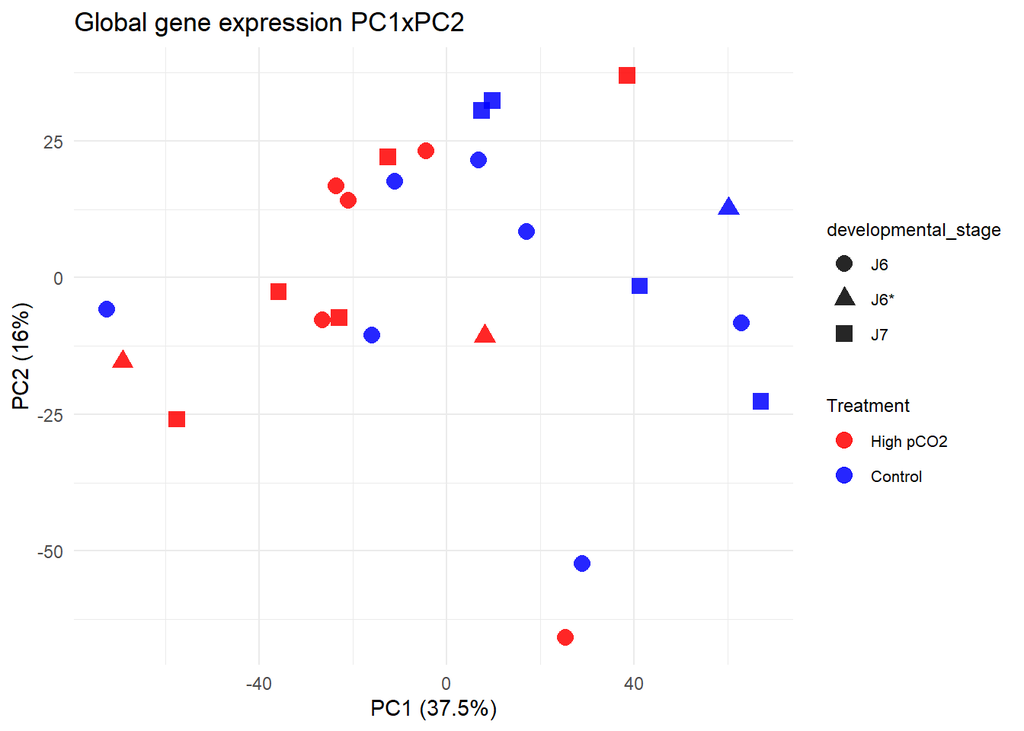

```r
ggscatter(tab.expr.annot,
          x="EV1.all", y="EV2.all", col="high_or_low_co2", shape="developmental_stage", size=3.5, alpha=0.85,
          ellipse = F, star.plot = F) +
  theme_minimal() + ggtitle("Global gene expression PC1xPC2") +
  scale_color_manual(name="Treatment",
                     values=c("L"="blue",
                              "H"="red"),
                     labels=c("L"="Control",
                              "H"="High pCO2")) +
  xlab(paste("PC1 (", round(pc.percent[1], digits = 1), "%)", sep="")) +
  ylab(paste("PC2 (", round(pc.percent[2], digits = 1), "%)", sep="")) +
  theme(legend.position = "right", legend.text=element_text(size=8), legend.title=element_text(size=9)) #+
```

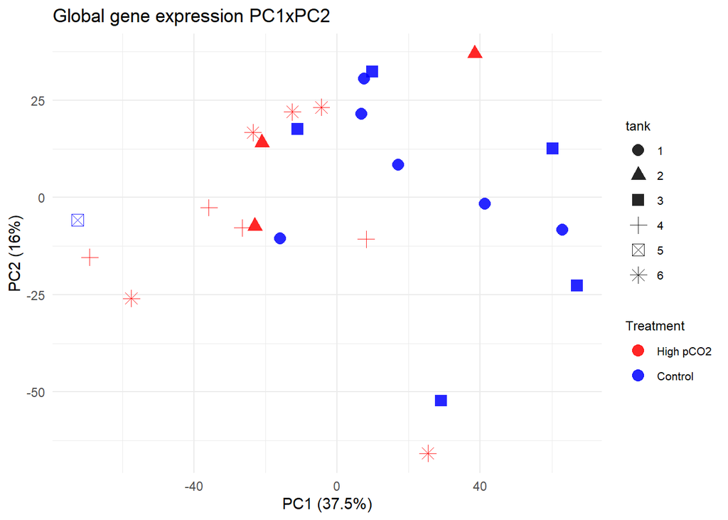

```r
  # scale_shape_manual(guide="none", values=c("L"=19, "H"=17)) +
  # guides(colour = guide_legend(override.aes = list(size=3.5, linetype="blank", shape=c(19, 17))))

ggscatter(tab.expr.annot,
          x="EV1.all", y="EV2.all", col="high_or_low_co2", shape="tank", size=3.5, alpha=0.85,
          ellipse = F, star.plot = F) +
  theme_minimal() + ggtitle("Global gene expression PC1xPC2") +
  scale_color_manual(name="Treatment",
                     values=c("L"="blue",
                              "H"="red"),
                     labels=c("L"="Control",
                              "H"="High pCO2")) +
  xlab(paste("PC1 (", round(pc.percent[1], digits = 1), "%)", sep="")) +
  ylab(paste("PC2 (", round(pc.percent[2], digits = 1), "%)", sep="")) +
  theme(legend.position = "right", legend.text=element_text(size=8), legend.title=element_text(size=9)) #+
```

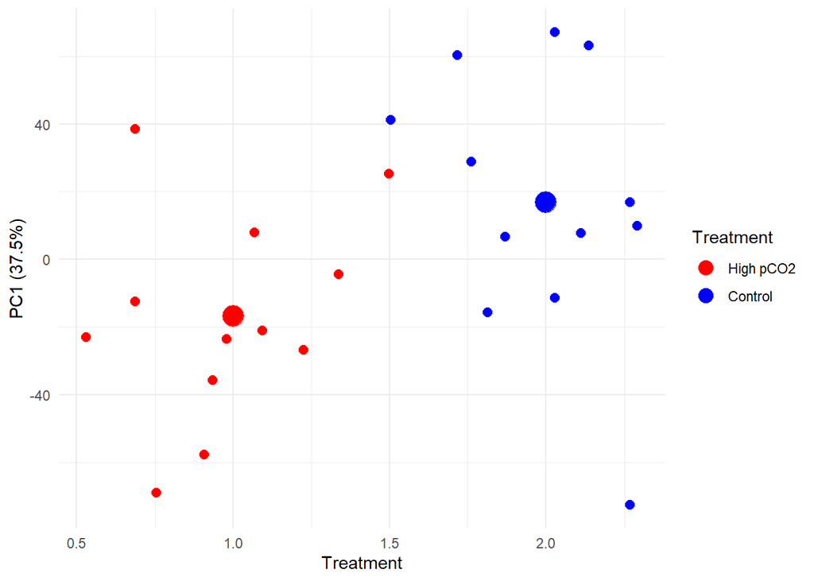

```r
ggplot() +
  geom_jitter(data= tab.expr.annot, width = 0.5, size=2.5,
              aes(x=as.numeric((high_or_low_co2)), y=EV1.all, color=high_or_low_co2)) +
  theme_minimal() + xlab("Treatment") + ylab(paste("PC1 (", round(pc.percent[1], digits = 1), "%)", sep="")) +
  scale_color_manual(name="Treatment", values=c("L"="blue","H"="red"), labels=c("L"="Control","H"="High pCO2")) +
  geom_point(data=tab.expr.annot %>% group_by(high_or_low_co2) %>% dplyr::summarise(stat = mean(EV1.all)),
      aes(x=as.numeric((high_or_low_co2)), y=stat, color=high_or_low_co2), size = 6) +
  guides(colour = guide_legend(override.aes = list(size=4, linetype="blank"), order=1),
         shape = guide_legend(override.aes = list(size=4, linetype="blank")))
```

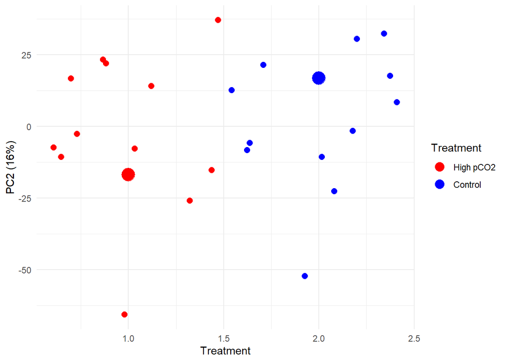

```r
ggplot() +
  geom_jitter(data= tab.expr.annot, width = 0.5, size=2.5,
              aes(x=as.numeric((high_or_low_co2)), y=EV2.all, color=high_or_low_co2)) +
  theme_minimal() + xlab("Treatment") + ylab(paste("PC2 (", round(pc.percent[2], digits = 1), "%)", sep="")) +
  scale_color_manual(name="Treatment", values=c("L"="blue","H"="red"), labels=c("L"="Control","H"="High pCO2")) +
  geom_point(data=tab.expr.annot %>% group_by(high_or_low_co2) %>% dplyr::summarise(stat = mean(EV1.all)),
      aes(x=as.numeric((high_or_low_co2)), y=stat, color=high_or_low_co2), size = 6) +
  guides(colour = guide_legend(override.aes = list(size=4, linetype="blank"), order=1),
         shape = guide_legend(override.aes = list(size=4, linetype="blank")))
```